# PCA and K-Means Iris Datasheet

Mochammad Arie Nugroho

12/23/2021

## Import Library

```r
knitr::opts_chunk$set(echo = TRUE)
library(tidyverse)
```

```r
library(ggplot2)
library(dplyr)
library(cluster)
library(factoextra)
```

### Instruksi

Dataset: Iris Task:

Lakukan PCA sehingga mereduksi data Iris menjadi 2 kolom saja kemudian, lakukan K-Means Clustering dari data Iris yang telah berhasil direduksi. Setelah itu, jawablah 3 soal di bawah ini:

Soal:

1. Berapa nilai eigenvalue 1 dan eigenvalue 2 dari dataset Iris?
2. Berapa informasi yang masih bisa ‘dijelaskan’ oleh data yang telah direduksi?
3. Cari nilai ‘k’ yang optimal berdasarkan Elbow dan Silhouette method. Apakah nilai k = 3 masih merupakan nilai ‘k’ yang terbaik?

Kumpulkan dalam R Markdown saja (.RMD) dan jangan format lain.

### Main Coding:

```r
# Import data iris
data(iris)

# Hilangkan kolom 'label' bunga sehingga data 'terkesan' seperti unlabeled
df <- cbind(iris$Sepal.Length, iris$Sepal.Width, iris$Petal.Length, iris$Petal.Width)
```

```r
# Buatlah PCA dari df
pca_iris = prcomp(df, center = TRUE, scale = TRUE)
```

```r
# Lihat summary model PCA untuk menentukan eigenvalue 1 dan 2
summary(pca_iris)
```

```
## Importance of components:
##                           PC1    PC2     PC3     PC4
## Standard deviation     1.7084 0.9560 0.38309 0.14393
## Proportion of Variance 0.7296 0.2285 0.03669 0.00518
## Cumulative Proportion  0.7296 0.9581 0.99482 1.00000
```

```r
# Lakukan kuadrat pada bagian 'standard deviation' untuk melihat eigenvalue
pca_iris$sdev^2
```

```
## [1] 2.91849782 0.91403047 0.14675688 0.02071484
```

```r
# Reduksilah data iris menjadi 2 kolom saja
iris_transform = as.data.frame(-pca_iris$x[,1:2])
```

```r
### Membuat dataframe baru dimana kolom pertama berisi 'row names' dari transformed data (yaitu berisi nama nama spesies)
new_data_iris = cbind(iris$Species, iris_transform)
```

```r
### Membuat nama spesies sebagai sebuah kolom sendiri, dan diberi nama kolom 'Species'
rownames(new_data_iris) = NULL
colnames(new_data_iris) = c('Species', 'PC1', 'PC2')
```

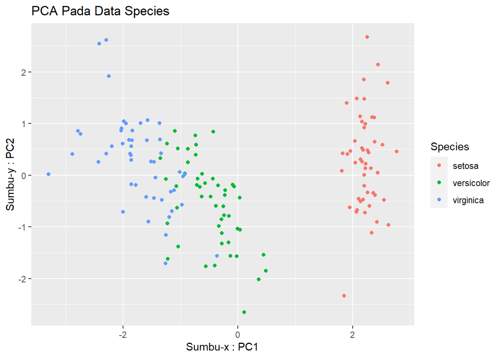

```r
ggplot(new_data_iris, aes(PC1, PC2,colour=Species)) +
  geom_point() +
  xlab("Sumbu-x : PC1") +
  ylab("Sumbu-y : PC2") +
  ggtitle("PCA Pada Data Species")
```

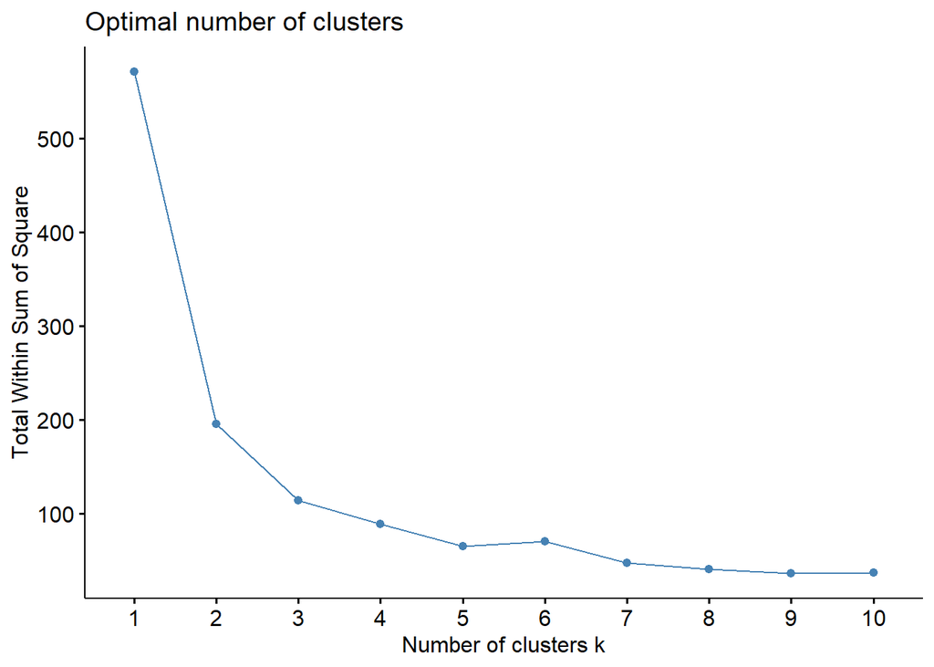

```r
# lakukan evaluasi k-means terhadap iris_transform
fviz_nbclust(iris_transform, kmeans, method = 'wss')
```

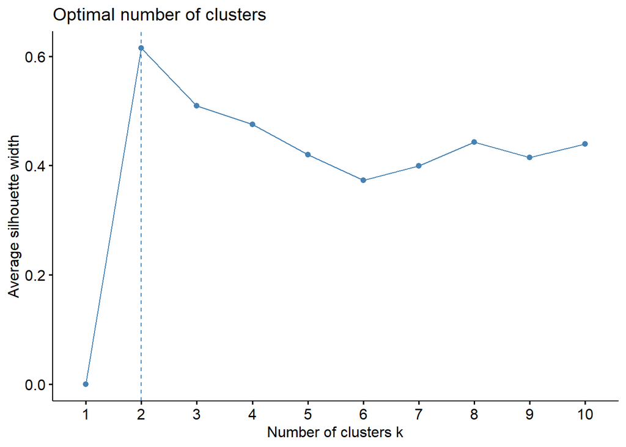

```r
fviz_nbclust(iris_transform, kmeans, method = 'silhouette')
```

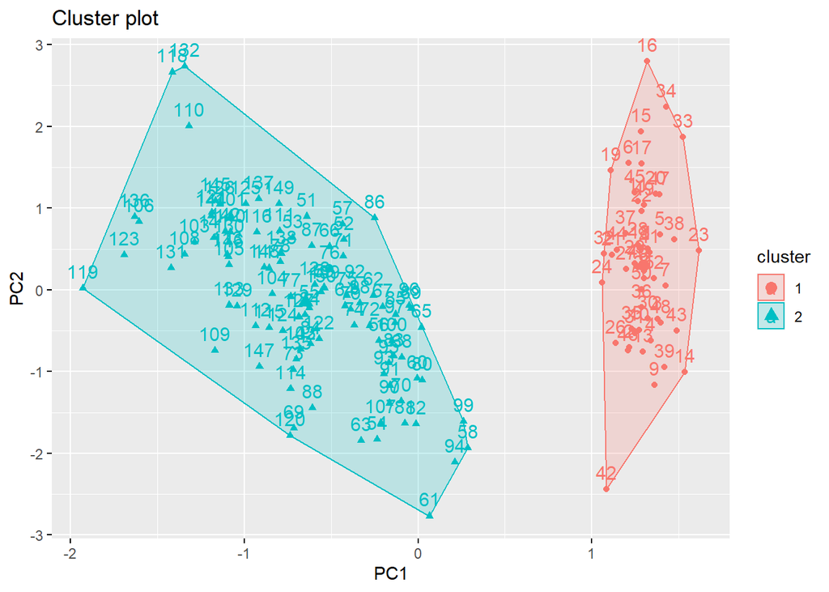

```r
# Visualisasikan k-means clustering pada data Iris yang telah tereduksi
kmeans_iris = kmeans(iris_transform, centers = 2, nstart = 50)
fviz_cluster(kmeans_iris, data = iris_transform)
```

### Summary :

a.Nilai eigenvalue 1 = 2.918497, Nilai eigenvalue 2 = 0.914030

b.informasi yang masih bisa ‘dijelaskan’ oleh data yang telah direduksi?

- Dengan menggunakan data yang telah direduksi dapat menampilkan 95.81% informasi dari data hanya dengan 2 principal component.
- Dari data 4 kolom, direduksi jadi 2 kolom saja. Ukuran berkurang 50%, tapi informasi yang terkandung hanya berkurang 4.19%.
- Dari visualisasi data yg didapat setelah data direduksi ditemukan bahwa species virginica dan versicolor memiliki ukuran sepal dan petal yang relatif mirip.
- Spesies setosa memiliki ukuran sepal dan petal yang jauh berbeda dengan Spesies Versicolor dan Virginica.

c.Nilai k yang optimal adalah k=2.